# Spatial Distribution of Octopus Fishery in Kilwa District

Masumbuko Semba, Silasi Mathew, Patroba Matiku and Muhaji Chande

November 28, 2018

# 1 Introduction

## 1.1 General Introduction

Several environmental factors affect the survival and distribution of fishes at early developmental stages. Some of these factors include: local hydrographic conditions, associated transport processes, seasonal variability, prey and predator densities, and the spawning patterns of adult fishes [1].

In their natural ocean habitat most species of Octopus are solitary and are described in poptflar accounts as territorial. They use crevices in the rock, empty shells, or spaces in a reef face as homes from which they go out to catch prey and to which they return to eat and rest [2].

## 1.2 Methods

### 1.2.1 Study Area

The data for this study were collected on coral reefs and shallow areas within the coastal water of Somanaga and Songosongo Island in Kilwa District (Figure 1.1).

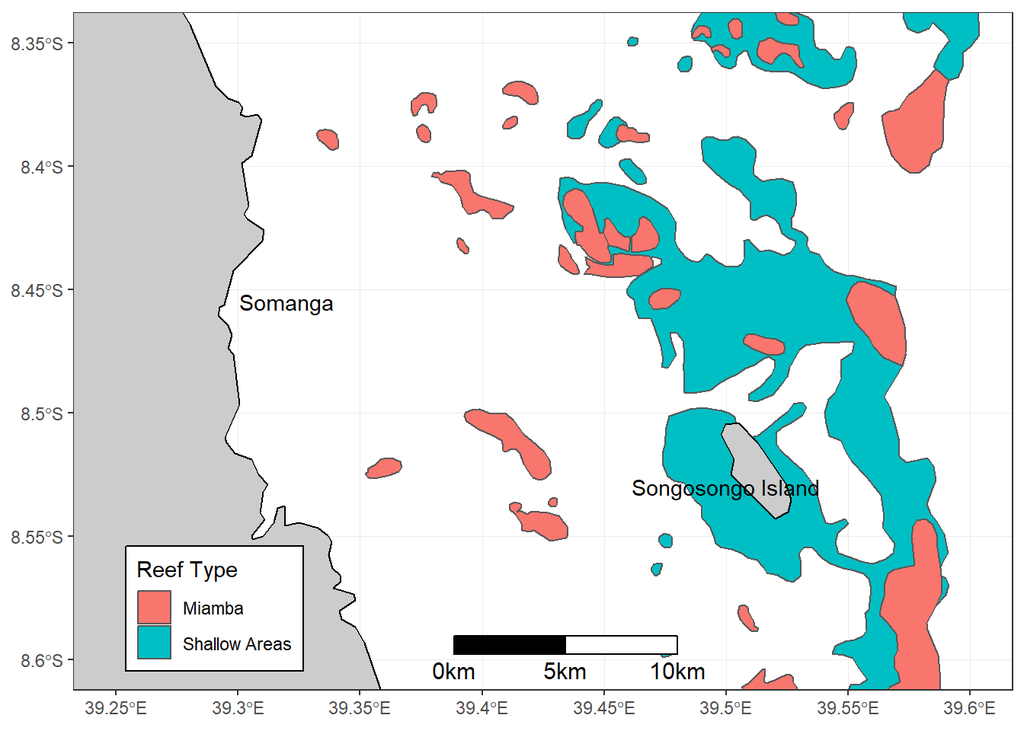

Figure 1.1: Reefs commonly used by octopus fishers

### 1.2.2 Octopus Catch Data

The monthly catch data were collected From November and December 2017 and January to March 2018.

### 1.2.3 Environmental Data

The CTD casts for environmental variables was done in November 2018. To measure both the environmental variables and spatial distribution with relation to coral reefs in the area CTD cast was used. The CTD measurments were done on the reef for relatively reefs with deeper water above 2 meters, and for shallow reefs that the boat could not reach, CTD cast were towed just after the reef where the water depth was sufficient to make a profile. The ctd was casted and in each cast it recorded profile of five variables— temperature, conductivity, depth, oxygen and fluorescence. A total of 30 CTD casts were recorded in two days . On 2018-11-24 sixteen CTD casts were recorded within the coastal water of Somanga and on the following day on the 2018-11-25 fourteen cast were recorded in coastal water around Songosongo Island.

### 1.2.4 Reef boundary

[interactive chart not shown]

Figure 1.2: Overlaid gps location on mapservices

## 1.3 Results

In the two sample areas—Somanga and Songosongo, both showed variation of catch rate over sampling months where fishermen at Songosongo catch bigger bigger octopus per fisherman compared to Somanga (figure 1.3).

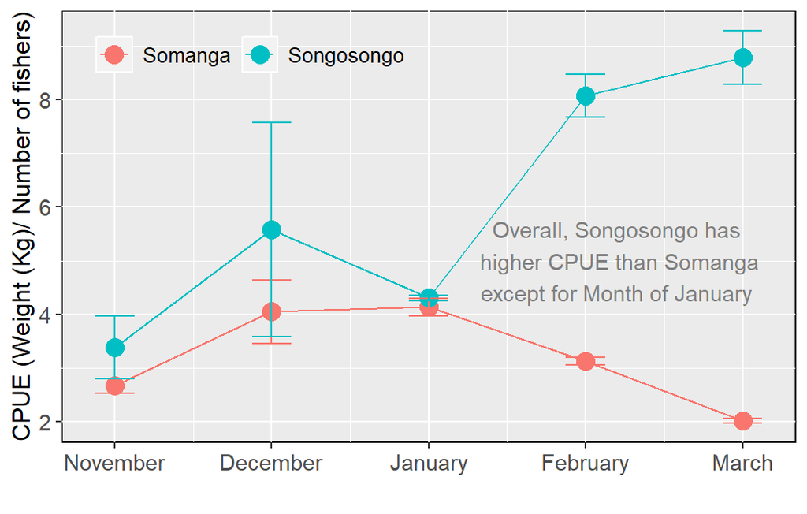

Figure 1.3: The mean Catch rate for octopus fishermen. error bar are standard deviation of the mean catch rate

The lower CPUE at Somanga is contributed by the number of octopus fisher in a single fishing vessels (figure 1.4). Four out of the five months of sampling, there were more fishermen in a a fishing vessels at Somanga than at Songosongo with exception of January, where the fishermen at Songosongo outnumber those at Somanga.

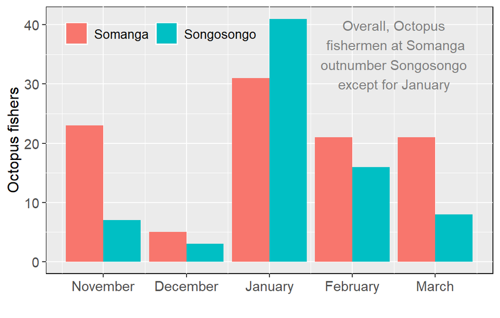

Figure 1.4: number of octopus fisher over the five month of field sampling

[output not shown]

Figure 1.5

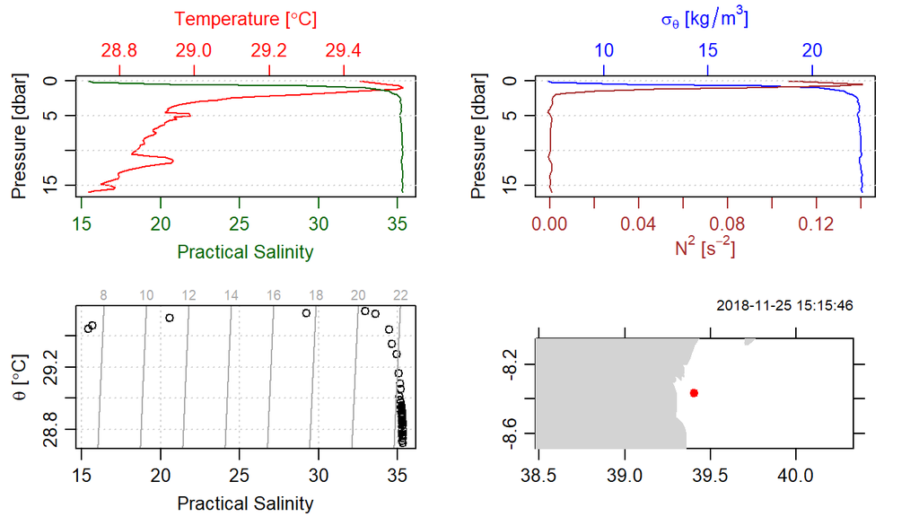

Figure 1.5: profiles of CTD

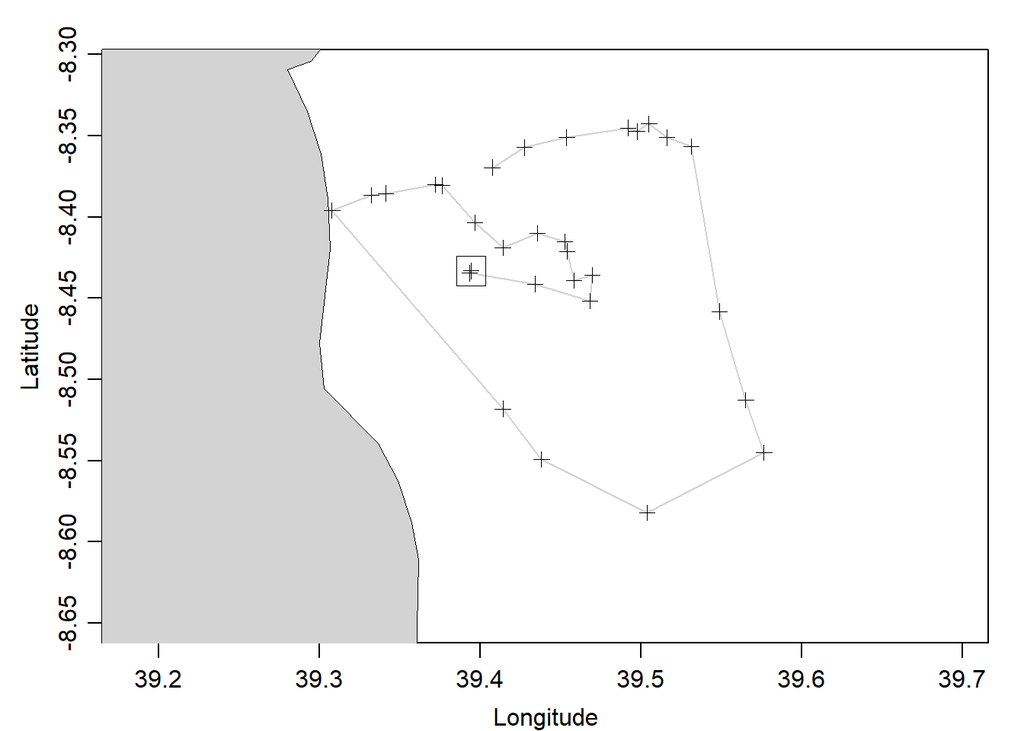

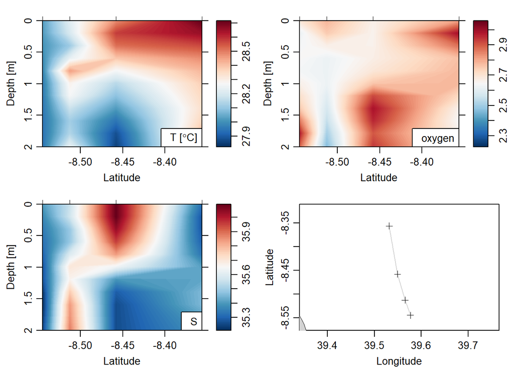

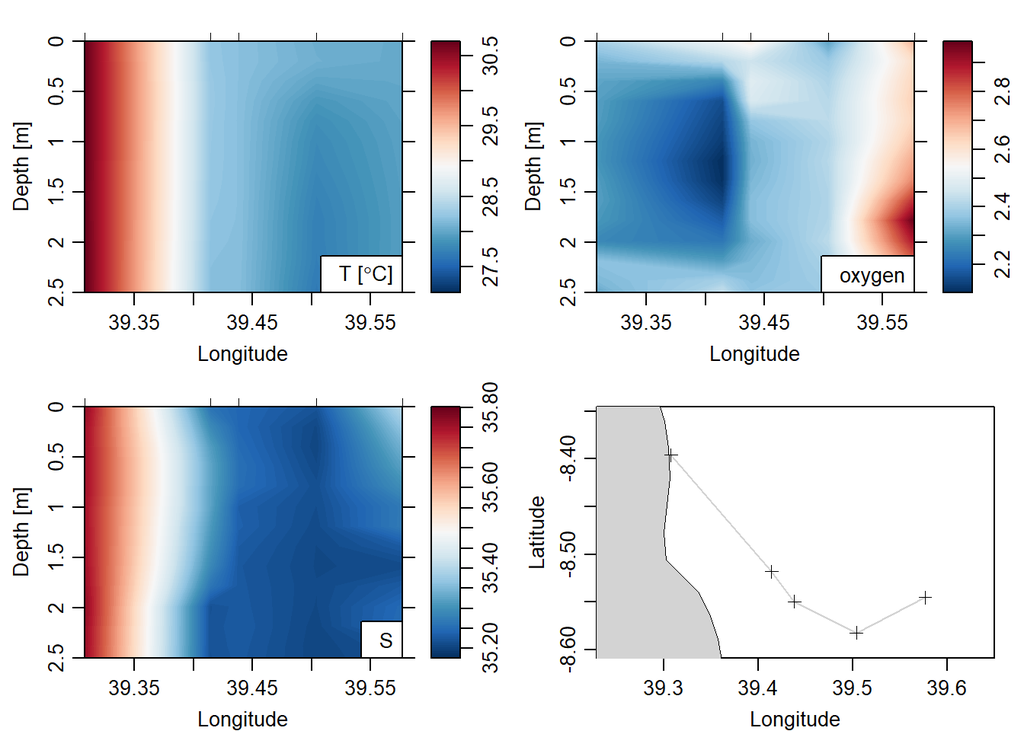

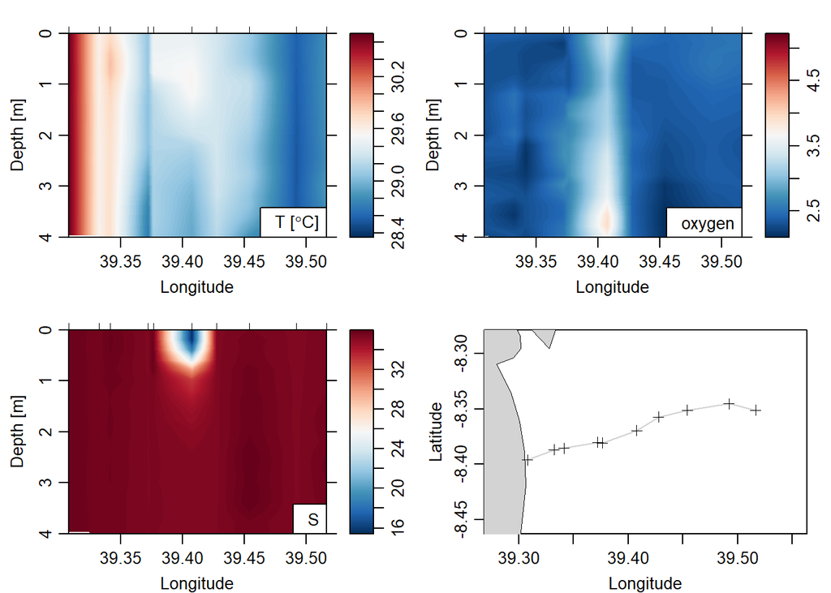

Figure 1.6

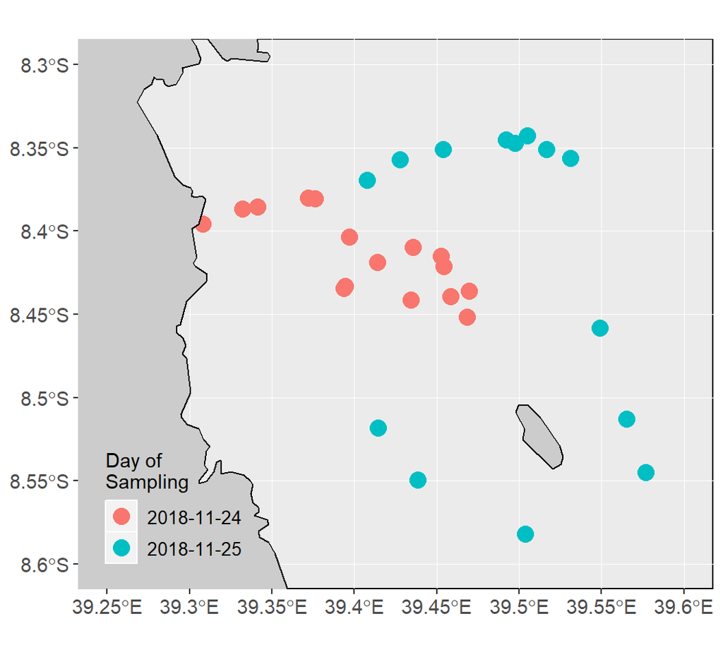

Figure 1.6: Locations of CTD casts

Profile and section plot could only answer the question relating to vertical structure of environmental variables along the transect. But for spatial distribution within the areas they are incapable. For example we wanted to know whether Were there areas that had higher environmental variables than others? The map in figure 1.7 show the spatial distribution of surface temperature in the songosongo and somanga areas. Darker-colored are areas that had relatively lower temperature, whereas the dark-pinked colored are had relatively higher temperature. Areas with higher temperatures in the northwest and most areas in the southeast with lower temperatures (Figure 1.7)

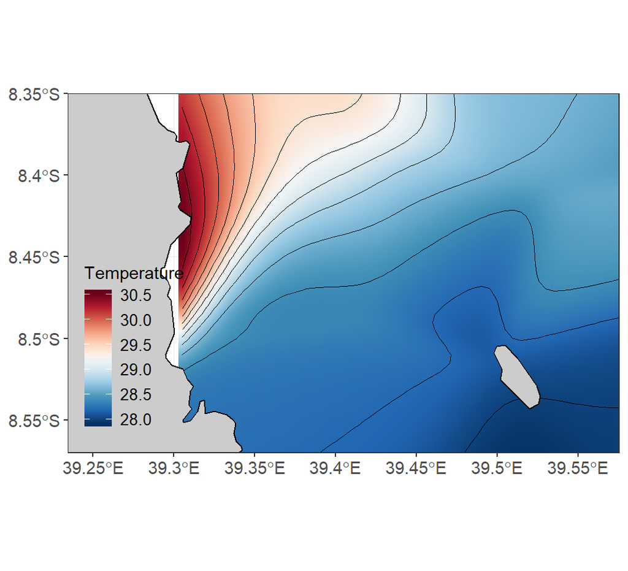

Figure 1.7: spatial distribution of temperature

Figure 1.8

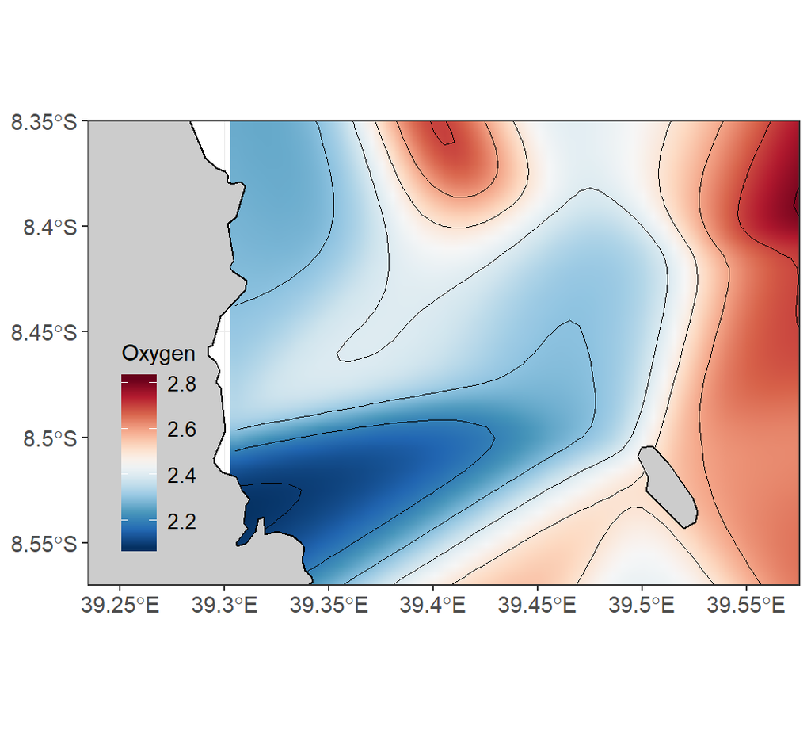

Figure 1.8: Spatial distribution of oxygen

Figure 1.9

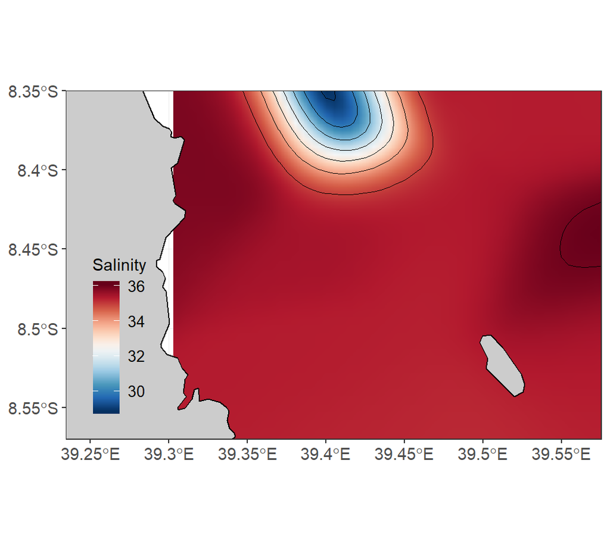

Figure 1.9: spatial distribution of salinity

Figure 1.10

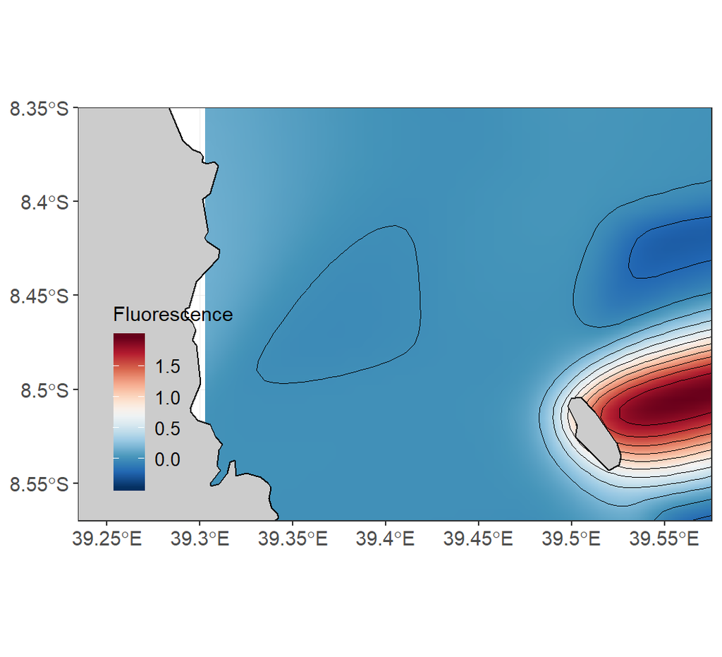

Figure 1.10: spatial distribution of fluorescence

## 1.5 Climatology SST and Chlorophyll-*a*

Figure 1.11 shows the monthly value of sst in the Somanga–Songosongo area.

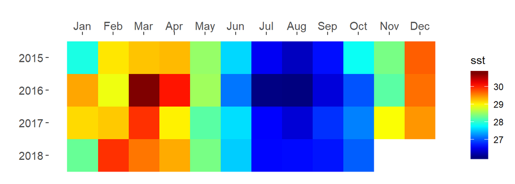

Figure 1.11: Monthly sea surface temperature within the areas of Somanga and Songosongo between 2015 and 2018

Figure 1.12 shows the monthly value of chlorophyll-a in the Somanga–Songosongo area.

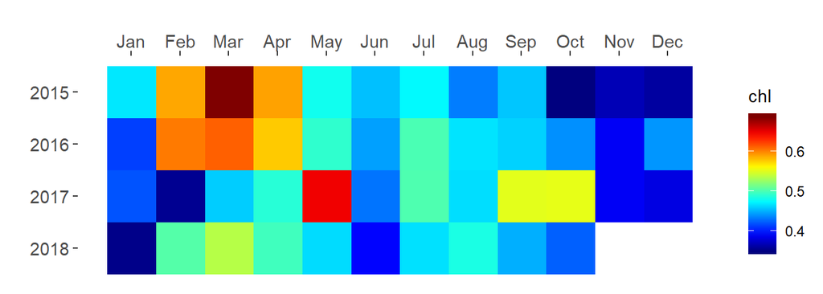

Figure 1.12: Monthly chlorophyll-a concentration within the areas of Somanga and Songosongo between 2015 and 2018

## References

1. Franco-Gordo C, Godínez-Domínguez E, Suárez-Morales E. Larval fish assemblages in waters off the central pacific coast of mexico. Journal of Plankton Research. 2002;24: 775–784. doi:10.1093/plankt/24.8.775

2. Mather JA. Factors affecting the spatial distribution of natural populations of octopus joubini robson. Animal Behaviour. Elsevier; 1982;30: 1166–1170.

3. R Core Team. R: A language and environment for statistical computing [Internet]. Vienna, Austria: R Foundation for Statistical Computing; 2018. Available: https://www.R-project.org/

4. Pebesma E. Simple Features for R: Standardized Support for Spatial Vector Data. The R Journal. 2018; Available: https://journal.r-project.org/archive/2018/RJ-2018-009/index.html

5. Appelhans T, Russell K. Mapedit: Interactive editing of spatial data in r [Internet]. 2018. Available: https://CRAN.R-project.org/package=mapedit

6. Appelhans T, Detsch F, Reudenbach C, Woellauer S. Mapview: Interactive viewing of spatial data in r [Internet]. 2018. Available: https://CRAN.R-project.org/package=mapview